# Crash Course in R - UNC Department of Statistics & Operations Research

We will assume a minimal statistics background in this tutorial–this is designed as a quick introduction to the R computing language for early undergraduates.

```r
#Installing relevant packages (first time):
install.packages("ggplot2")
install.packages("gdata")
install.packages("faraway")
```

```r
#Load the packages:
library("ggplot2")
library("gdata")
library("faraway")
```

## Introductory Data Manipulation

Set working directory:

```r
setwd("/Users/Nikolai/Documents/R Files") #change as needed
```

Import titanic3.csv data (make sure it is placed in appropriate working directory):

```r
tdat <- read.csv("titanic3.csv")
```

Let’s observe the first 10 rows of tdat.

```r
head(tdat, n=10)
```

|  | pclass | survived | name | sex | age | sibsp | parch | ticket | fare | cabin | embarked | boat | body | home.dest |
| --- | --- | --- | --- | --- | --- | --- | --- | --- | --- | --- | --- | --- | --- | --- |
| 1 | 1 | 1 | Allen, Miss. Elisabeth Walton | female | 29.00 | 0 | 0 | 24160 | 211.3375 | B5 | S | 2 | NA | St Louis, MO |
| 2 | 1 | 1 | Allison, Master. Hudson Trevor | male | 0.92 | 1 | 2 | 113781 | 151.5500 | C22 C26 | S | 11 | NA | Montreal, PQ / Chesterville, ON |
| 3 | 1 | 0 | Allison, Miss. Helen Loraine | female | 2.00 | 1 | 2 | 113781 | 151.5500 | C22 C26 | S |  | NA | Montreal, PQ / Chesterville, ON |
| 4 | 1 | 0 | Allison, Mr. Hudson Joshua Creighton | male | 30.00 | 1 | 2 | 113781 | 151.5500 | C22 C26 | S |  | 135 | Montreal, PQ / Chesterville, ON |
| 5 | 1 | 0 | Allison, Mrs. Hudson J C (Bessie Waldo Daniels) | female | 25.00 | 1 | 2 | 113781 | 151.5500 | C22 C26 | S |  | NA | Montreal, PQ / Chesterville, ON |
| 6 | 1 | 1 | Anderson, Mr. Harry | male | 48.00 | 0 | 0 | 19952 | 26.5500 | E12 | S | 3 | NA | New York, NY |
| 7 | 1 | 1 | Andrews, Miss. Kornelia Theodosia | female | 63.00 | 1 | 0 | 13502 | 77.9583 | D7 | S | 10 | NA | Hudson, NY |
| 8 | 1 | 0 | Andrews, Mr. Thomas Jr | male | 39.00 | 0 | 0 | 112050 | 0.0000 | A36 | S |  | NA | Belfast, NI |
| 9 | 1 | 1 | Appleton, Mrs. Edward Dale (Charlotte Lamson) | female | 53.00 | 2 | 0 | 11769 | 51.4792 | C101 | S | D | NA | Bayside, Queens, NY |
| 10 | 1 | 0 | Artagaveytia, Mr. Ramon | male | 71.00 | 0 | 0 | PC 17609 | 49.5042 |  | C |  | 22 | Montevideo, Uruguay |

Or the last 10.

```r
tail(tdat, n=10)
```

|  | pclass | survived | name | sex | age | sibsp | parch | ticket | fare | cabin | embarked | boat | body | home.dest |
| --- | --- | --- | --- | --- | --- | --- | --- | --- | --- | --- | --- | --- | --- | --- |
| 1300 | 3 | 0 | Yasbeck, Mr. Antoni | male | 27.0 | 1 | 0 | 2659 | 14.4542 |  | C | C | NA |  |
| 1301 | 3 | 1 | Yasbeck, Mrs. Antoni (Selini Alexander) | female | 15.0 | 1 | 0 | 2659 | 14.4542 |  | C |  | NA |  |
| 1302 | 3 | 0 | Youseff, Mr. Gerious | male | 45.5 | 0 | 0 | 2628 | 7.2250 |  | C |  | 312 |  |
| 1303 | 3 | 0 | Yousif, Mr. Wazli | male | NA | 0 | 0 | 2647 | 7.2250 |  | C |  | NA |  |
| 1304 | 3 | 0 | Yousseff, Mr. Gerious | male | NA | 0 | 0 | 2627 | 14.4583 |  | C |  | NA |  |
| 1305 | 3 | 0 | Zabour, Miss. Hileni | female | 14.5 | 1 | 0 | 2665 | 14.4542 |  | C |  | 328 |  |
| 1306 | 3 | 0 | Zabour, Miss. Thamine | female | NA | 1 | 0 | 2665 | 14.4542 |  | C |  | NA |  |
| 1307 | 3 | 0 | Zakarian, Mr. Mapriededer | male | 26.5 | 0 | 0 | 2656 | 7.2250 |  | C |  | 304 |  |
| 1308 | 3 | 0 | Zakarian, Mr. Ortin | male | 27.0 | 0 | 0 | 2670 | 7.2250 |  | C |  | NA |  |
| 1309 | 3 | 0 | Zimmerman, Mr. Leo | male | 29.0 | 0 | 0 | 315082 | 7.8750 |  | S |  | NA |  |

If we just want to call the variables names, we can use:

```r
names(tdat)
```

```
 [1] "pclass"    "survived"  "name"      "sex"       "age"       "sibsp"     "parch"
 [8] "ticket"    "fare"      "cabin"     "embarked"  "boat"      "body"      "home.dest"
```

We can also observe the structure of the dataframe with the following command:

```r
str(tdat)
```

```
'data.frame':   1309 obs. of  14 variables:
 $ pclass   : int  1 1 1 1 1 1 1 1 1 1 ...
 $ survived : int  1 1 0 0 0 1 1 0 1 0 ...
 $ name     : Factor w/ 1307 levels "Abbing, Mr. Anthony",..: 22 24 25 26 27 31 46 47 51 55 ...
 $ sex      : Factor w/ 2 levels "female","male": 1 2 1 2 1 2 1 2 1 2 ...
 $ age      : num  29 0.92 2 30 25 48 63 39 53 71 ...
 $ sibsp    : int  0 1 1 1 1 0 1 0 2 0 ...
 $ parch    : int  0 2 2 2 2 0 0 0 0 0 ...
 $ ticket   : Factor w/ 929 levels "110152","110413",..: 188 50 50 50 50 125 93 16 77 826 ...
 $ fare     : num  211 152 152 152 152 ...
 $ cabin    : Factor w/ 187 levels "","A10","A11",..: 45 81 81 81 81 151 147 17 63 1 ...
 $ embarked : Factor w/ 4 levels "","C","Q","S": 4 4 4 4 4 4 4 4 4 2 ...
 $ boat     : Factor w/ 28 levels "","1","10","11",..: 13 4 1 1 1 14 3 1 28 1 ...
 $ body     : int  NA NA NA 135 NA NA NA NA NA 22 ...
 $ home.dest: Factor w/ 370 levels "","?Havana, Cuba",..: 310 232 232 232 232 238 163 25 23 230 ...
```

Call data summary to see a bigger picture.

```r
summary(tdat)
```

```
     pclass         survived                                   name          sex
 Min.   :1.000   Min.   :0.000   Connolly, Miss. Kate            :   2   female:466
 1st Qu.:2.000   1st Qu.:0.000   Kelly, Mr. James                :   2   male  :843
 Median :3.000   Median :0.000   Abbing, Mr. Anthony             :   1
 Mean   :2.295   Mean   :0.382   Abbott, Master. Eugene Joseph   :   1
 3rd Qu.:3.000   3rd Qu.:1.000   Abbott, Mr. Rossmore Edward     :   1
 Max.   :3.000   Max.   :1.000   Abbott, Mrs. Stanton (Rosa Hunt):   1
                                 (Other)                         :1301
      age            sibsp            parch            ticket          fare
 Min.   : 0.17   Min.   :0.0000   Min.   :0.000   CA. 2343:  11   Min.   :  0.000
 1st Qu.:21.00   1st Qu.:0.0000   1st Qu.:0.000   1601    :   8   1st Qu.:  7.896
 Median :28.00   Median :0.0000   Median :0.000   CA 2144 :   8   Median : 14.454
 Mean   :29.88   Mean   :0.4989   Mean   :0.385   3101295 :   7   Mean   : 33.295
 3rd Qu.:39.00   3rd Qu.:1.0000   3rd Qu.:0.000   347077  :   7   3rd Qu.: 31.275
 Max.   :80.00   Max.   :8.0000   Max.   :9.000   347082  :   7   Max.   :512.329
 NA's   :263                                      (Other) :1261   NA's   :1
             cabin      embarked      boat          body                      home.dest
                :1014    :  2           :823   Min.   :  1.0                       :564
 C23 C25 C27    :   6   C:270    13     : 39   1st Qu.: 72.0   New York, NY        : 64
 B57 B59 B63 B66:   5   Q:123    C      : 38   Median :155.0   London              : 14
 G6             :   5   S:914    15     : 37   Mean   :160.8   Montreal, PQ        : 10
 B96 B98        :   4            14     : 33   3rd Qu.:256.0   Cornwall / Akron, OH:  9
 C22 C26        :   4            4      : 31   Max.   :328.0   Paris, France       :  9
 (Other)        : 271            (Other):308   NA's   :1188    (Other)             :639
```

We have 14 variables across 1309 observations (seen from the environment display); pclass, survived, name, sex, age, sibsp, parch, ticket, fare, cabin, embarked, boat, body, home.dest Notice the way the summaries differ for strings vs. numerical data. Keep in mind that some numerical data is categorical. “survived”, for instance, is binary and it would not make sense to find quantiles and averages for that variable. We see we have integer, numerical, and factor variables. Factors are the string-type variables.

Note that “boat” is considered a factor as it refers to boat number, so taking an average of boat numbers would not make sense (would you take an average of zip-codes?).

In statistical practice, columns are always associated with the different variables while rows are associated with the different observations.

I can extract a single column and treat it as a separate data vector.

```r
age <- tdat$age
head(age,n=5) #first 5 ages
```

```
[1] 29.00  0.92  2.00 30.00 25.00
```

```r
age[1] #I can examine an individual index of the vector. This shows me the 1st age in the list.
```

```
[1] 29
```

```r
summary(age) #Viewing the summary of age, I have a bunch of "NA" terms. These correspond to blank entries in the original data file.
```

```
   Min. 1st Qu.  Median    Mean 3rd Qu.    Max.    NA's
   0.17   21.00   28.00   29.88   39.00   80.00     263
```

```r
var(age, na.rm=TRUE) #We can calculate the variance of the data for "age" while excluding blank values with the na.rm=TRUE command.
```

```
[1] 207.7488
```

```r
sqrt(var(age, na.rm=TRUE)) #gives us our standard deviation for "age".
```

```
[1] 14.41349
```

## Subsetting Data

Let’s create a new dataframe “tdat_sub” that we will treat as a subdataframe for us to play with.

```r
tdat_sub <- tdat
```

We now want to produce a dataframe based on a subset of the columns. Recall our variable names.

```r
names(tdat)
```

```
 [1] "pclass"    "survived"  "name"      "sex"       "age"       "sibsp"     "parch"
 [8] "ticket"    "fare"      "cabin"     "embarked"  "boat"      "body"      "home.dest"
```

Let us keep “pclass”, “survived”, “sex”, “age”, and “fare”.

```r
keep <- c("pclass", "survived", "sex", "age", "fare") #gives us a vector of strings defining the variables (columns) we wish to keep.
tdat_sub <- tdat_sub[keep] #overwrite tdat_sub--be careful with overwriting! If you're not sure whether you wish to overwrite, better to create a new variable to manipulate!
summary(tdat_sub)
```

```
     pclass         survived         sex           age             fare
 Min.   :1.000   Min.   :0.000   female:466   Min.   : 0.17   Min.   :  0.000
 1st Qu.:2.000   1st Qu.:0.000   male  :843   1st Qu.:21.00   1st Qu.:  7.896
 Median :3.000   Median :0.000                Median :28.00   Median : 14.454
 Mean   :2.295   Mean   :0.382                Mean   :29.88   Mean   : 33.295
 3rd Qu.:3.000   3rd Qu.:1.000                3rd Qu.:39.00   3rd Qu.: 31.275
 Max.   :3.000   Max.   :1.000                Max.   :80.00   Max.   :512.329
                                              NA's   :263     NA's   :1
```

And we have our summary of the reduced dataframe.

Suppose we want a summary of an individual passenger.

```r
tdat[1,] #summary for the first passenger. Not specifying the second argument in the indexing gives us all values (columns) for row 1.
```

|  | pclass | survived | name | sex | age | sibsp | parch | ticket | fare | cabin | embarked | boat | body | home.dest |
| --- | --- | --- | --- | --- | --- | --- | --- | --- | --- | --- | --- | --- | --- | --- |
| 1 | 1 | 1 | Allen, Miss. Elisabeth Walton | female | 29 | 0 | 0 | 24160 | 211.3375 | B5 | S | 2 | NA | St Louis, MO |

```r
first_passenger <- tdat[1,] #assign the first row to variable "first_passenger".
first_passenger["fare"] #We can also extract the value for the particular variable as follows.
```

|  | fare |
| --- | --- |
| 1 | 211.3375 |

Let’s combine row and column subsetting. The following will give us a 10x3 data frame of the first 10 rows with the variables: “pclass”, “survived”, and “name”.

```r
keep2 <- c("pclass", "survived", "name")
subset <- tdat[1:10,keep2]
subset
```

|  | pclass | survived | name |
| --- | --- | --- | --- |
| 1 | 1 | 1 | Allen, Miss. Elisabeth Walton |
| 2 | 1 | 1 | Allison, Master. Hudson Trevor |
| 3 | 1 | 0 | Allison, Miss. Helen Loraine |
| 4 | 1 | 0 | Allison, Mr. Hudson Joshua Creighton |
| 5 | 1 | 0 | Allison, Mrs. Hudson J C (Bessie Waldo Daniels) |
| 6 | 1 | 1 | Anderson, Mr. Harry |
| 7 | 1 | 1 | Andrews, Miss. Kornelia Theodosia |
| 8 | 1 | 0 | Andrews, Mr. Thomas Jr |
| 9 | 1 | 1 | Appleton, Mrs. Edward Dale (Charlotte Lamson) |
| 10 | 1 | 0 | Artagaveytia, Mr. Ramon |

The binary variable “survived” takes on value 1 if the person survived, and 0 if they did not. We can subset based on logical tests. We will take our 10x3 data frame and reduce it to a subdataframe containing just the survivors.

```r
subset_surv <- subset[subset$survived == 1,] #keep rows where the value of "survived" is 1 while retaining all columns.
subset_surv
```

|  | pclass | survived | name |
| --- | --- | --- | --- |
| 1 | 1 | 1 | Allen, Miss. Elisabeth Walton |
| 2 | 1 | 1 | Allison, Master. Hudson Trevor |
| 6 | 1 | 1 | Anderson, Mr. Harry |
| 7 | 1 | 1 | Andrews, Miss. Kornelia Theodosia |
| 9 | 1 | 1 | Appleton, Mrs. Edward Dale (Charlotte Lamson) |

We can now subset the larger data file “tdat” by survivors.

```r
tdat_surv <- tdat[tdat$survived == 1,]
summary(tdat_surv)
```

```
     pclass         survived                                        name         sex
 Min.   :1.000   Min.   :1   Abbott, Mrs. Stanton (Rosa Hunt)         :  1   female:339
 1st Qu.:1.000   1st Qu.:1   Abelseth, Miss. Karen Marie              :  1   male  :161
 Median :2.000   Median :1   Abelseth, Mr. Olaus Jorgensen            :  1
 Mean   :1.962   Mean   :1   Abelson, Mrs. Samuel (Hannah Wizosky)    :  1
 3rd Qu.:3.000   3rd Qu.:1   Abrahamsson, Mr. Abraham August Johannes :  1
 Max.   :3.000   Max.   :1   Abrahim, Mrs. Joseph (Sophie Halaut Easu):  1
                             (Other)                                  :494
      age            sibsp           parch            ticket         fare
 Min.   : 0.17   Min.   :0.000   Min.   :0.000   1601    :  6   Min.   :  0.00
 1st Qu.:20.00   1st Qu.:0.000   1st Qu.:0.000   PC 17608:  6   1st Qu.: 11.21
 Median :28.00   Median :0.000   Median :0.000   16966   :  5   Median : 26.00
 Mean   :28.92   Mean   :0.462   Mean   :0.476   113760  :  4   Mean   : 49.36
 3rd Qu.:38.00   3rd Qu.:1.000   3rd Qu.:1.000   19950   :  4   3rd Qu.: 57.75
 Max.   :80.00   Max.   :4.000   Max.   :5.000   230136  :  4   Max.   :512.33
 NA's   :73                                      (Other) :471
             cabin     embarked      boat          body                    home.dest
                :307    :  2    13     : 39   Min.   : NA                       :153
 B57 B59 B63 B66:  4   C:150    15     : 37   1st Qu.: NA   New York, NY        : 40
 B96 B98        :  4   Q: 44    C      : 37   Median : NA   Cornwall / Akron, OH:  8
 C23 C25 C27    :  4   S:304    14     : 32   Mean   :NaN   Paris, France       :  8
 F33            :  4            4      : 31   3rd Qu.: NA   Brooklyn, NY        :  5
 F4             :  4            10     : 29   Max.   : NA   London              :  5
 (Other)        :173            (Other):295   NA's   :500   (Other)             :281
```

```r
tdat_surv[1:10,]
```

|  | pclass | survived | name | sex | age | sibsp | parch | ticket | fare | cabin | embarked | boat | body | home.dest |
| --- | --- | --- | --- | --- | --- | --- | --- | --- | --- | --- | --- | --- | --- | --- |
| 1 | 1 | 1 | Allen, Miss. Elisabeth Walton | female | 29.00 | 0 | 0 | 24160 | 211.3375 | B5 | S | 2 | NA | St Louis, MO |
| 2 | 1 | 1 | Allison, Master. Hudson Trevor | male | 0.92 | 1 | 2 | 113781 | 151.5500 | C22 C26 | S | 11 | NA | Montreal, PQ / Chesterville, ON |
| 6 | 1 | 1 | Anderson, Mr. Harry | male | 48.00 | 0 | 0 | 19952 | 26.5500 | E12 | S | 3 | NA | New York, NY |
| 7 | 1 | 1 | Andrews, Miss. Kornelia Theodosia | female | 63.00 | 1 | 0 | 13502 | 77.9583 | D7 | S | 10 | NA | Hudson, NY |
| 9 | 1 | 1 | Appleton, Mrs. Edward Dale (Charlotte Lamson) | female | 53.00 | 2 | 0 | 11769 | 51.4792 | C101 | S | D | NA | Bayside, Queens, NY |
| 12 | 1 | 1 | Astor, Mrs. John Jacob (Madeleine Talmadge Force) | female | 18.00 | 1 | 0 | PC 17757 | 227.5250 | C62 C64 | C | 4 | NA | New York, NY |
| 13 | 1 | 1 | Aubart, Mme. Leontine Pauline | female | 24.00 | 0 | 0 | PC 17477 | 69.3000 | B35 | C | 9 | NA | Paris, France |
| 14 | 1 | 1 | Barber, Miss. Ellen "Nellie" | female | 26.00 | 0 | 0 | 19877 | 78.8500 |  | S | 6 | NA |  |
| 15 | 1 | 1 | Barkworth, Mr. Algernon Henry Wilson | male | 80.00 | 0 | 0 | 27042 | 30.0000 | A23 | S | B | NA | Hessle, Yorks |
| 18 | 1 | 1 | Baxter, Mrs. James (Helene DeLaudeniere Chaput) | female | 50.00 | 0 | 1 | PC 17558 | 247.5208 | B58 B60 | C | 6 | NA | Montreal, PQ |

Note the change in summary details and the skipped observation indices from the first 10 observations in our subsetted data.

We can also subset based on multiple criteria. We wish to subset survivors not in first class.

```r
tdat_surv2 <- tdat[with(tdat, survived == 1 & pclass %in% c(2,3)),]
summary(tdat_surv2)
```

```
     pclass         survived                                        name         sex
 Min.   :2.000   Min.   :1   Abbott, Mrs. Stanton (Rosa Hunt)         :  1   female:200
 1st Qu.:2.000   1st Qu.:1   Abelseth, Miss. Karen Marie              :  1   male  :100
 Median :3.000   Median :1   Abelseth, Mr. Olaus Jorgensen            :  1
 Mean   :2.603   Mean   :1   Abelson, Mrs. Samuel (Hannah Wizosky)    :  1
 3rd Qu.:3.000   3rd Qu.:1   Abrahamsson, Mr. Abraham August Johannes :  1
 Max.   :3.000   Max.   :1   Abrahim, Mrs. Joseph (Sophie Halaut Easu):  1
                             (Other)                                  :294
      age            sibsp          parch          ticket         fare
 Min.   : 0.17   Min.   :0.00   Min.   :0.00   1601   :  6   Min.   : 0.000
 1st Qu.:16.00   1st Qu.:0.00   1st Qu.:0.00   230136 :  4   1st Qu.: 7.894
 Median :24.00   Median :0.00   Median :0.00   2666   :  4   Median :13.000
 Mean   :23.09   Mean   :0.43   Mean   :0.51   220845 :  3   Mean   :16.920
 3rd Qu.:31.00   3rd Qu.:1.00   3rd Qu.:1.00   248738 :  3   3rd Qu.:22.519
 Max.   :63.00   Max.   :4.00   Max.   :5.00   26360  :  3   Max.   :65.000
 NA's   :54                                    (Other):277
     cabin     embarked      boat          body
        :274    :  0    13     : 38   Min.   : NA
 F33    :  4   C: 53    15     : 36   1st Qu.: NA
 F4     :  4   Q: 42    C      : 35   Median : NA
 E101   :  3   S:205    14     : 28   Mean   :NaN
 G6     :  3            16     : 23   3rd Qu.: NA
 D      :  2                   : 22   Max.   : NA
 (Other): 10            (Other):118   NA's   :300
                              home.dest
                                   :128
 Cornwall / Akron, OH              :  8
 London                            :  5
 Guntur, India / Benton Harbour, MI:  4
 New York, NY                      :  4
 Syria New York, NY                :  4
 (Other)                           :147
```

```r
tdat_surv2[1:10]
```

|  | pclass | survived | name | sex | age | sibsp | parch | ticket | fare | cabin |
| --- | --- | --- | --- | --- | --- | --- | --- | --- | --- | --- |
| 325 | 2 | 1 | Abelson, Mrs. Samuel (Hannah Wizosky) | female | 28.00 | 1 | 0 | P/PP 3381 | 24.0000 |  |
| 330 | 2 | 1 | Angle, Mrs. William A (Florence "Mary" Agnes Hughes) | female | 36.00 | 1 | 0 | 226875 | 26.0000 |  |
| 334 | 2 | 1 | Ball, Mrs. (Ada E Hall) | female | 36.00 | 0 | 0 | 28551 | 13.0000 | D |
| 337 | 2 | 1 | Beane, Mr. Edward | male | 32.00 | 1 | 0 | 2908 | 26.0000 |  |
| 338 | 2 | 1 | Beane, Mrs. Edward (Ethel Clarke) | female | 19.00 | 1 | 0 | 2908 | 26.0000 |  |
| 340 | 2 | 1 | Becker, Master. Richard F | male | 1.00 | 2 | 1 | 230136 | 39.0000 | F4 |
| 341 | 2 | 1 | Becker, Miss. Marion Louise | female | 4.00 | 2 | 1 | 230136 | 39.0000 | F4 |
| 342 | 2 | 1 | Becker, Miss. Ruth Elizabeth | female | 12.00 | 2 | 1 | 230136 | 39.0000 | F4 |
| 343 | 2 | 1 | Becker, Mrs. Allen Oliver (Nellie E Baumgardner) | female | 36.00 | 0 | 3 | 230136 | 39.0000 | F4 |
| 344 | 2 | 1 | Beesley, Mr. Lawrence | male | 34.00 | 0 | 0 | 248698 | 13.0000 | D56 |

[output cut: 290 more lines]

Looks like 3/5 of the survivors were from classes 2 and 3.

We can also use the subset() function with logical arguments. Let’s subset survivors less than or equal to age 30.

```r
tdat_survLEQ30 <- subset(tdat_surv, age <= 30)
summary(tdat_survLEQ30)
```

```
     pclass         survived                                        name         sex
 Min.   :1.000   Min.   :1   Abelseth, Miss. Karen Marie              :  1   female:166
 1st Qu.:1.000   1st Qu.:1   Abelseth, Mr. Olaus Jorgensen            :  1   male  : 82
 Median :2.000   Median :1   Abelson, Mrs. Samuel (Hannah Wizosky)    :  1
 Mean   :2.161   Mean   :1   Abrahamsson, Mr. Abraham August Johannes :  1
 3rd Qu.:3.000   3rd Qu.:1   Abrahim, Mrs. Joseph (Sophie Halaut Easu):  1
 Max.   :3.000   Max.   :1   Aks, Master. Philip Frank                :  1
                             (Other)                                  :242
      age            sibsp            parch            ticket         fare
 Min.   : 0.17   Min.   :0.0000   Min.   :0.0000   2666   :  4   Min.   :  0.00
 1st Qu.:15.00   1st Qu.:0.0000   1st Qu.:0.0000   19950  :  3   1st Qu.:  9.50
 Median :21.00   Median :0.0000   Median :0.0000   230136 :  3   Median : 19.26
 Mean   :18.80   Mean   :0.5161   Mean   :0.6129   248738 :  3   Mean   : 39.57
 3rd Qu.:25.00   3rd Qu.:1.0000   3rd Qu.:1.0000   2650   :  3   3rd Qu.: 39.94
 Max.   :30.00   Max.   :4.0000   Max.   :3.0000   2653   :  3   Max.   :263.00
                                                   (Other):229
             cabin     embarked      boat          body
                :173    :  0    13     : 25   Min.   : NA
 B57 B59 B63 B66:  3   C: 71    15     : 23   1st Qu.: NA
 C23 C25 C27    :  3   Q: 11    C      : 21   Median : NA
 F33            :  3   S:166    10     : 18   Mean   :NaN
 F4             :  3            14     : 18   3rd Qu.: NA
 G6             :  3            11     : 17   Max.   : NA
 (Other)        : 60            (Other):126   NA's   :248
                              home.dest
                                   : 77
 New York, NY                      : 12
 Cornwall / Akron, OH              :  7
 Syria New York, NY                :  4
 Bangkok, Thailand / Roseville, IL :  3
 Guntur, India / Benton Harbour, MI:  3
 (Other)                           :142
```

```r
tdat_survLEQ30[1:10]
```

|  | pclass | survived | name | sex | age | sibsp | parch | ticket | fare | cabin |
| --- | --- | --- | --- | --- | --- | --- | --- | --- | --- | --- |
| 1 | 1 | 1 | Allen, Miss. Elisabeth Walton | female | 29.00 | 0 | 0 | 24160 | 211.3375 | B5 |
| 2 | 1 | 1 | Allison, Master. Hudson Trevor | male | 0.92 | 1 | 2 | 113781 | 151.5500 | C22 C26 |
| 12 | 1 | 1 | Astor, Mrs. John Jacob (Madeleine Talmadge Force) | female | 18.00 | 1 | 0 | PC 17757 | 227.5250 | C62 C64 |
| 13 | 1 | 1 | Aubart, Mme. Leontine Pauline | female | 24.00 | 0 | 0 | PC 17477 | 69.3000 | B35 |
| 14 | 1 | 1 | Barber, Miss. Ellen "Nellie" | female | 26.00 | 0 | 0 | 19877 | 78.8500 |  |
| 23 | 1 | 1 | Behr, Mr. Karl Howell | male | 26.00 | 0 | 0 | 111369 | 30.0000 | C148 |
| 25 | 1 | 1 | Bird, Miss. Ellen | female | 29.00 | 0 | 0 | PC 17483 | 221.7792 | C97 |
| 27 | 1 | 1 | Bishop, Mr. Dickinson H | male | 25.00 | 1 | 0 | 11967 | 91.0792 | B49 |
| 28 | 1 | 1 | Bishop, Mrs. Dickinson H (Helen Walton) | female | 19.00 | 1 | 0 | 11967 | 91.0792 | B49 |
| 30 | 1 | 1 | Bjornstrom-Steffansson, Mr. Mauritz Hakan | male | 28.00 | 0 | 0 | 110564 | 26.5500 | C52 |

[output cut: 238 more lines]

If we examine “tdat_survLEQ30”, we find that there are no observations containing N/A for the “age” variable. Those were dropped by the logical (make sure you understand the caveats of dropping observations from a model; you also have the option of replacing empty values with an estimator determined from the nonempty data). In an ideal dataset, there are no missing values, but this rarely happens in the real world.

```r
high_fare_adults <- subset(tdat, fare >= 100 & age >= 18 & age <= 60 | is.na(tdat$age))
summary(high_fare_adults)
```

```
     pclass         survived                                                     name
 Min.   :1.000   Min.   :0.0000   Allen, Miss. Elisabeth Walton                    :  1
 1st Qu.:1.000   1st Qu.:0.0000   Allison, Mr. Hudson Joshua Creighton             :  1
 Median :3.000   Median :0.0000   Allison, Mrs. Hudson J C (Bessie Waldo Daniels)  :  1
 Mean   :2.313   Mean   :0.3708   Astor, Col. John Jacob                           :  1
 3rd Qu.:3.000   3rd Qu.:1.0000   Astor, Mrs. John Jacob (Madeleine Talmadge Force):  1
 Max.   :3.000   Max.   :1.0000   Baumann, Mr. John D                              :  1
                                  (Other)                                          :323
     sex           age            sibsp            parch             ticket
 female:123   Min.   :18.00   Min.   :0.0000   Min.   :0.0000   CA. 2343: 10
 male  :206   1st Qu.:28.25   1st Qu.:0.0000   1st Qu.:0.0000   113503  :  5
              Median :36.00   Median :0.0000   Median :0.0000   19950   :  5
              Mean   :37.20   Mean   :0.5167   Mean   :0.3435   4133    :  5
              3rd Qu.:46.50   3rd Qu.:1.0000   3rd Qu.:0.0000   PC 17608:  5
              Max.   :60.00   Max.   :8.0000   Max.   :9.0000   PC 17757:  5
              NA's   :263                                       (Other) :294
      fare                    cabin     embarked      boat          body
 Min.   :  0.00                  :251    :  0           :212   Min.   : 45.0
 1st Qu.:  7.75   C23 C25 C27    :  5   C:100    4      : 14   1st Qu.:107.0
 Median : 14.50   B57 B59 B63 B66:  3   Q: 73    16     : 13   Median :129.5
 Mean   : 55.63   B58 B60        :  3   S:156    3      : 12   Mean   :127.5
 3rd Qu.: 69.55   B51 B53 B55    :  2            C      : 11   3rd Qu.:148.5
 Max.   :512.33   B78            :  2            8      : 10   Max.   :232.0
                  (Other)        : 63            (Other): 57   NA's   :321
          home.dest
               :220
 New York, NY  : 13
 Belfast       :  7
 Winnipeg, MB  :  6
 Paris, France :  4
 Youngstown, OH:  4
 (Other)       : 75
```

```r
high_fare_adults[1:10]
```

|  | pclass | survived | name | sex | age | sibsp | parch | ticket | fare | cabin |
| --- | --- | --- | --- | --- | --- | --- | --- | --- | --- | --- |
| 1 | 1 | 1 | Allen, Miss. Elisabeth Walton | female | 29.0 | 0 | 0 | 24160 | 211.3375 | B5 |
| 4 | 1 | 0 | Allison, Mr. Hudson Joshua Creighton | male | 30.0 | 1 | 2 | 113781 | 151.5500 | C22 C26 |
| 5 | 1 | 0 | Allison, Mrs. Hudson J C (Bessie Waldo Daniels) | female | 25.0 | 1 | 2 | 113781 | 151.5500 | C22 C26 |
| 11 | 1 | 0 | Astor, Col. John Jacob | male | 47.0 | 1 | 0 | PC 17757 | 227.5250 | C62 C64 |
| 12 | 1 | 1 | Astor, Mrs. John Jacob (Madeleine Talmadge Force) | female | 18.0 | 1 | 0 | PC 17757 | 227.5250 | C62 C64 |
| 16 | 1 | 0 | Baumann, Mr. John D | male | NA | 0 | 0 | PC 17318 | 25.9250 |  |
| 17 | 1 | 0 | Baxter, Mr. Quigg Edmond | male | 24.0 | 0 | 1 | PC 17558 | 247.5208 | B58 B60 |
| 18 | 1 | 1 | Baxter, Mrs. James (Helene DeLaudeniere Chaput) | female | 50.0 | 0 | 1 | PC 17558 | 247.5208 | B58 B60 |
| 24 | 1 | 1 | Bidois, Miss. Rosalie | female | 42.0 | 0 | 0 | PC 17757 | 227.5250 |  |
| 25 | 1 | 1 | Bird, Miss. Ellen | female | 29.0 | 0 | 0 | PC 17483 | 221.7792 | C97 |

[output cut: 319 more lines]

Let’s see what sort of statistics we can calculate using our newest subset.

```r
mean(high_fare_adults[,5], na.rm=TRUE) #We will have trouble without na.rm=TRUE due to NA values. This will allow us to calculate the mean of the existing values.
```

```
[1] 37.20455
```

```r
mean(high_fare_adults[,"age"], na.rm=TRUE) #gives us the same thing.
```

```
[1] 37.20455
```

```r
var(high_fare_adults[,"age"], na.rm=TRUE)
```

```
[1] 138.0844
```

## Data Visualisation

Let’s now produce some plots of our data.. Let’s produce a histogram for the variable “age”.

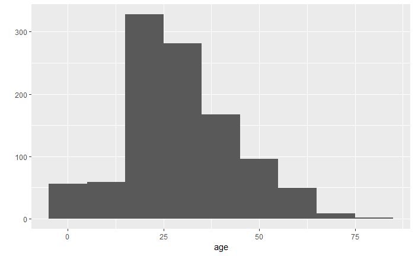

```r
qplot(age, data=tdat, geom="histogram", binwidth=10)
```

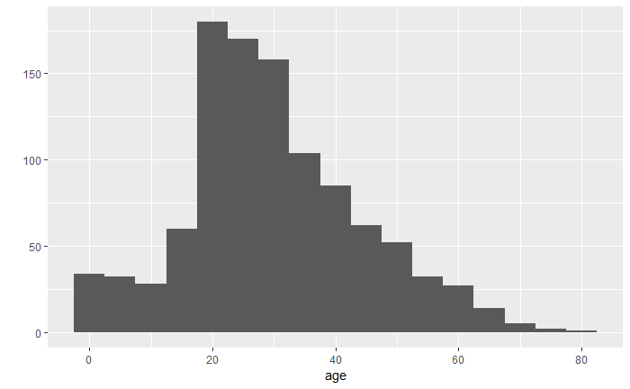

```r
qplot(age, data=tdat, geom="histogram", binwidth=5)
```

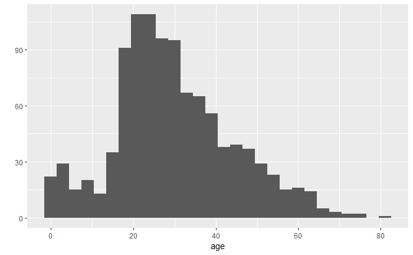

```r
qplot(age, data=tdat, geom="histogram", binwidth=3)
```

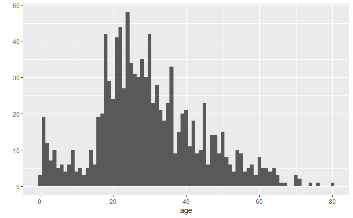

```r
qplot(age, data=tdat, geom="histogram", binwidth=1)
```

Remember, a histogram creates “classes” based on bins (consecutive intervals of the variable).

We can also create a scatterplot of two variables against each other which helps us examine trends. Note that we can add additional commands to capture binary differences in the data.

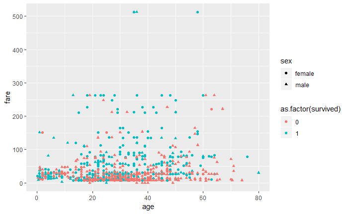

```r
ggplot() + geom_point(data=tdat, mapping=aes(x=age, y=fare, shape=sex, color=as.factor(survived))) #we use as.factor(survived) to prevent R from treating it as a continuous variable on [0,1].
```

We can also produce box-and-whisker plots for examine 5-number-summaries (min, $Q_1$, median, $Q_3$, max)

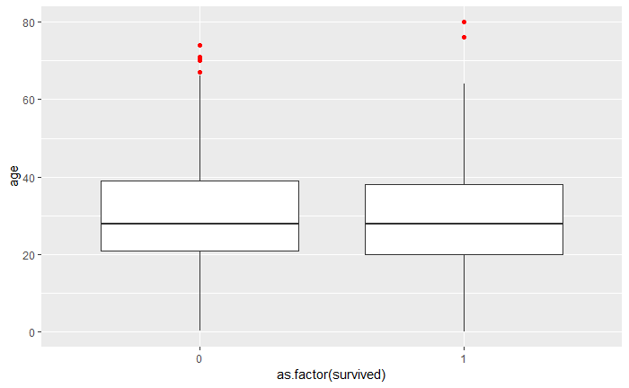

```r
ggplot() + geom_boxplot(data=tdat, aes(x=as.factor(survived), y=age), outlier.colour="red")
```

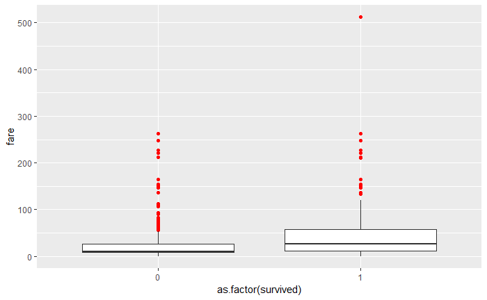

```r
ggplot() + geom_boxplot(data=tdat, aes(x=as.factor(survived), y=fare), outlier.colour="red")
```

R uses a simple interquartile range (IQR) outlier classification rule for boxplots.

## Linear Models

We will use a different dataset for building a linear model of the form $Y = \beta_0 + \beta_1 X_1 + \dots + \beta_p X_p$ where $Y$ is a dependent variable on the independent variables $X_1, \dots , X_p$. We will use the following accompanying package for Julian Faraway’s Linear Models with R text.

```r
data(divusa, package="faraway")
summary(divusa)
```

```
      year         divorce        unemployed         femlab         marriage
 Min.   :1920   Min.   : 6.10   Min.   : 1.200   Min.   :22.70   Min.   : 49.70
 1st Qu.:1939   1st Qu.: 8.70   1st Qu.: 4.200   1st Qu.:27.47   1st Qu.: 61.90
 Median :1958   Median :10.60   Median : 5.600   Median :37.10   Median : 74.10
 Mean   :1958   Mean   :13.27   Mean   : 7.173   Mean   :38.58   Mean   : 72.97
 3rd Qu.:1977   3rd Qu.:20.30   3rd Qu.: 7.500   3rd Qu.:47.80   3rd Qu.: 80.00
 Max.   :1996   Max.   :22.80   Max.   :24.900   Max.   :59.30   Max.   :118.10
     birth           military
 Min.   : 65.30   Min.   : 1.940
 1st Qu.: 68.90   1st Qu.: 3.469
 Median : 85.90   Median : 9.102
 Mean   : 88.89   Mean   :12.365
 3rd Qu.:107.30   3rd Qu.:14.266
 Max.   :122.90   Max.   :86.641
```

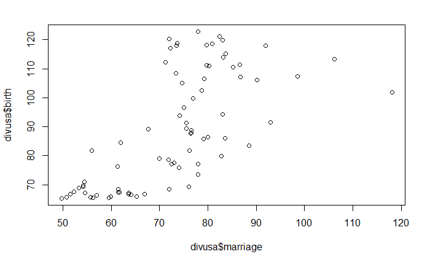

```r
plot(divusa$marriage, divusa$birth)
```

One might reasonably think there is a strong correlation between “marriage” and “birth”. We see from the scatterplot that there seems to be a loose positive correlation. To fit the model $Y_{birth} = \beta_0 + \beta_{marriage} X_{marriage}$, we use the lm() function.

```r
lmod <- lm(birth ~ marriage, data=divusa)
summary(lmod)
```

```
Call:
lm(formula = birth ~ marriage, data = divusa)

Residuals:
    Min      1Q  Median      3Q     Max
-32.205  -9.993  -1.072   9.360  32.286

Coefficients:
            Estimate Std. Error t value Pr(>|t|)
(Intercept)  15.7706     9.4073   1.676   0.0978 .
marriage      1.0020     0.1269   7.896 1.89e-11 ***
---
Signif. codes:  0 ‘***’ 0.001 ‘**’ 0.01 ‘*’ 0.05 ‘.’ 0.1 ‘ ’ 1

Residual standard error: 14.52 on 75 degrees of freedom
Multiple R-squared:  0.4539,    Adjusted R-squared:  0.4466
F-statistic: 62.34 on 1 and 75 DF,  p-value: 1.885e-11
```

Our summary gives us estimates $\hat{\beta}_{0} = 15.7706, \hat{\beta}_{marriage} = 1.0020$.

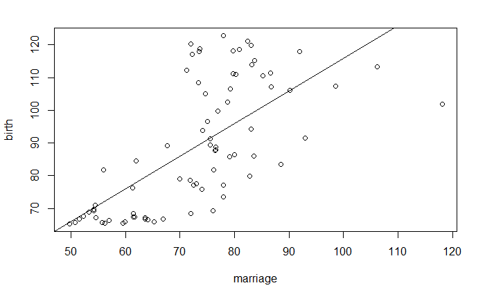

```r
with(divusa,plot(marriage, birth))
abline(lmod)
```

We can extend linear models to $X_1, \dots , X_p$ as mentioned before. An example might be to try to explain “divorce” as a linear function of the other variables except for “year”.

```r
lmod2 <- lm(divorce ~ unemployed + femlab + marriage + birth + military, data=divusa)
summary(lmod2)
```

```
Call:
lm(formula = divorce ~ unemployed + femlab + marriage + birth +
    military, data = divusa)

Residuals:
    Min      1Q  Median      3Q     Max
-3.8611 -0.8916 -0.0496  0.8650  3.8300

Coefficients:
            Estimate Std. Error t value Pr(>|t|)
(Intercept)  2.48784    3.39378   0.733   0.4659
unemployed  -0.11125    0.05592  -1.989   0.0505 .
femlab       0.38365    0.03059  12.543  < 2e-16 ***
marriage     0.11867    0.02441   4.861 6.77e-06 ***
birth       -0.12996    0.01560  -8.333 4.03e-12 ***
military    -0.02673    0.01425  -1.876   0.0647 .
---
Signif. codes:  0 ‘***’ 0.001 ‘**’ 0.01 ‘*’ 0.05 ‘.’ 0.1 ‘ ’ 1

Residual standard error: 1.65 on 71 degrees of freedom
Multiple R-squared:  0.9208,    Adjusted R-squared:  0.9152
F-statistic: 165.1 on 5 and 71 DF,  p-value: < 2.2e-16
```

An understanding of applied statistics is needed to interpret the significance of each $X_i$ in the above table as well as assess the overall fit.

## General Linear Models & Classification (In Progress)

What was the survival rate of the passengers?

```r
mean(tdat$survived)
```

```
[1] 0.381971
```

It was approximately 38.2%.

Can we imagine what sorts of variables may give us a clear seperating boundary for survivability? Let’s try the variable “sex”.

```r
males <- subset(tdat, sex == "male")
females <- subset(tdat, sex == "female")
mean(males$survived)
```

```
[1] 0.1909846
```

```r
mean(females$survived)
```

```
[1] 0.7274678
```

We see an approximate 19.1% survival rate for males and 72.7% survival rate for females. A simple classification rule would be: If $sex = male \rightarrow survived = 0$ If $sex = female \rightarrow survived = 1$. What would our classification accuracy be under this rule? Let $n$ be the total number of observations, $M$ be the number of non-surviving males, and $F$ be the number of surviving females. $\frac{M+F}{n}$ is our expected classification accuracy given the data.

```r
(nrow(males[males$survived == 0,]) + nrow(females[females$survived == 1,])) / nrow(tdat)
```

```
[1] 0.7799847
```

So our expected classification accuracy is approximately 80% given this rule.

What if we wish to incorporate more than just one variable in our classification? We can use a form of regression to produce a classification rule. In order to do this, we will need to split our data into training and validation sets (for validating the classification rule).

We will use a training set size of 80% of the data (rounded down).

```r
train_size <- floor(0.8*nrow(tdat))
train_size #Our training set size.
```

```
[1] 1047
```

```r
set.seed(12345) #Setting a base for the RNG.
train_idx <- sample(seq_len(nrow(tdat)), size=train_size)
train <- tdat[train_idx,]
valid <- tdat[-train_idx,]
```

We now have our training and validation sets. Let us create a probit regression model. This is a form of “general linear model” (GLM). We will have to specify a link function as “probit” within the glm() function. We will use the following predictors: “sex”, “age”, “sibsp”, “parch”, and “fare” as predictors for the binary response “survived”.

```r
probit_model <- glm(survived ~ sex + age + sibsp + parch + fare, family=binomial(link="probit"), data=train) #Don't forget to use the training data, or else we might accidentaly validate the model based on data we used to train it!
summary(probit_model)
```

```
Call:
glm(formula = survived ~ sex + age + sibsp + parch + fare, family = binomial(link = "probit"),
    data = train)

Deviance Residuals:
    Min       1Q   Median       3Q      Max
-2.4123  -0.6655  -0.5405   0.7485   2.3362

Coefficients:
             Estimate Std. Error z value Pr(>|z|)
(Intercept)  0.873838   0.145856   5.991 2.08e-09 ***
sexmale     -1.535007   0.105130 -14.601  < 2e-16 ***
age         -0.010594   0.003774  -2.807 0.005004 **
sibsp       -0.223739   0.064174  -3.486 0.000489 ***
parch       -0.019316   0.067251  -0.287 0.773946
fare         0.006681   0.001272   5.253 1.50e-07 ***
---
Signif. codes:  0 ‘***’ 0.001 ‘**’ 0.01 ‘*’ 0.05 ‘.’ 0.1 ‘ ’ 1

(Dispersion parameter for binomial family taken to be 1)

    Null deviance: 1127.09  on 834  degrees of freedom
Residual deviance:  818.31  on 829  degrees of freedom
  (212 observations deleted due to missingness)
AIC: 830.31

Number of Fisher Scoring iterations: 5
```

Some understanding of applied statistics is needed to understand the the implications of this summary. Note that all models are wrong, but some provide better information than others. We must consider whether we selected good predictors (do we add more or remove some–maybe both?). We will not go into these details in this course.

```r
pred_probs <- predict(probit_model, newdata = valid, type = "response")
pred_probs[1:10]
```

```
        1         9        13        27        33        48        50        52        59
0.9760645 0.5827058 0.8604997 0.2941601 0.9512868 0.1760619 0.9908841 0.1641975 0.1570747
       72
0.3985315
```

As classification rule from the probit regression is: If our predicted response is $>$ 0.5, classify as a survivor. If otherwise, classify as a nonsurvivor. Not that the predicted responses are in $(0,1)$.

Note that some predicted responses have the “NA” value. This is due to “NA” in the predictors. For fixing the “NA” values in the predictors we can consider averages, interpolation, or regression approaches (with the missing predcitor as the new response). These considerations are discussed in an applied statistics course.